## Assignment 1

#### Due Friday, February 21

Turn in an HTML file and this R Markdown file after you have edited it.

### Data

The assignment uses both the original Madison weather data file, `madison-weather.csv`, and the official data `madison-weather-official.csv`. You may certainly copy and reuse code from lecture as needed.

### Problems

```r
mw = mw %>%
    mutate(NAME = case_when(
        NAME == "ARBORETUM UNIVERSITY WIS, WI US" ~ "Arboretum",
        NAME == "CHARMANY FARM, WI US" ~ "Charmany",
        NAME == "MADISON DANE CO REGIONAL AIRPORT, WI US" ~ "Airport",
        NAME == "MADISON WEATHER BUREAU CITY, WI US" ~ "Bureau",
        TRUE ~ NAME)) %>%
    select(-STATION,-ELEVATION,-starts_with("L")) %>%
    rename("name"=NAME,
           "date"=DATE,
           "prcp"=PRCP,
           "snow"=SNOW,
           "tmax"=TMAX,
           "tmin"=TMIN)
```

### 1

Use the full Madison weather data set. Create a smaller data set that has each day where both the Madison Weather Bureau and the Airport have both `tmax` and `tmin` measured without missing data. Keep the date, name of the weather station, and these two tempertures, but eliminate the other variables and observations from the other two weather stations. What are the earliest and latest dates, how many observations are there, and how many dates are missing?

Answer: The earliest date of the data set is the first of January, 1869, and the latest date is December 31st, 2019. There are over fifty-five thousand observations, 55144 to be exact, with 7 days of missing data.

```r
#P1
problem_1 = mw %>%
  select(name,date,tmax,tmin) %>%
  filter(name == "Airport" | name == "Bureau") %>%
  pivot_wider(names_from = name, values_from = c("tmax","tmin"))

p1_mw_sum = problem_1 %>%
    summarize(first = min(date),
              last = max(date),
              n = n(),
              missing_dates = (last - first + 1) - n,
              na_tmax_a = sum(is.na(tmax_Airport)),
              na_tmin_a = sum(is.na(tmin_Airport)),
              na_tmax_b = sum(is.na(tmax_Bureau)),
              na_tmin_b = sum(is.na(tmin_Bureau))
              ) %>%
    arrange(first)

p1_mw_sum %>% as.data.frame()
```

```
##        first       last     n missing_dates na_tmax_a na_tmin_a na_tmax_b
## 1 1869-01-01 2019-12-31 55144        7 days     25832     25832     20785
##   na_tmin_b
## 1     20788
```

### 2

Using the data set from the previous problem, calculate the difference (Airport minus Weather Bureau) of the maximum temperature recorded on each day and plot these differences with a histogram. Describe the notable features of this distribution. What are the mean and standard deviation? What are the median and lower and upper quartiles? What are the most extreme differences in each direction?

```r
#P2
problem_2 = problem_1%>%
  select(date, tmax_Airport, tmax_Bureau)%>%
  drop_na(tmax_Airport, tmax_Bureau)%>%
  mutate(dif_max =
           tmax_Airport-tmax_Bureau,)
p2_mw_sum = problem_2%>%
  summarise(avg = mean(dif_max),
            dev = sd(dif_max),
            med = median(dif_max),
            iqr = IQR(dif_max))
  drop_na(problem_2, dif_max)
```

```
## # A tibble: 8,530 x 4
##    date       tmax_Airport tmax_Bureau dif_max
##    <date>            <dbl>       <dbl>   <dbl>
##  1 1939-10-01           67          67       0
##  2 1939-10-02           70          69       1
##  3 1939-10-03           74          74       0
##  4 1939-10-04           81          80       1
##  5 1939-10-05           70          75      -5
##  6 1939-10-06           77          73       4
##  7 1939-10-07           85          84       1
##  8 1939-10-08           79          82      -3
##  9 1939-10-09           75          75       0
## 10 1939-10-10           67          70      -3
## # ... with 8,520 more rows
```

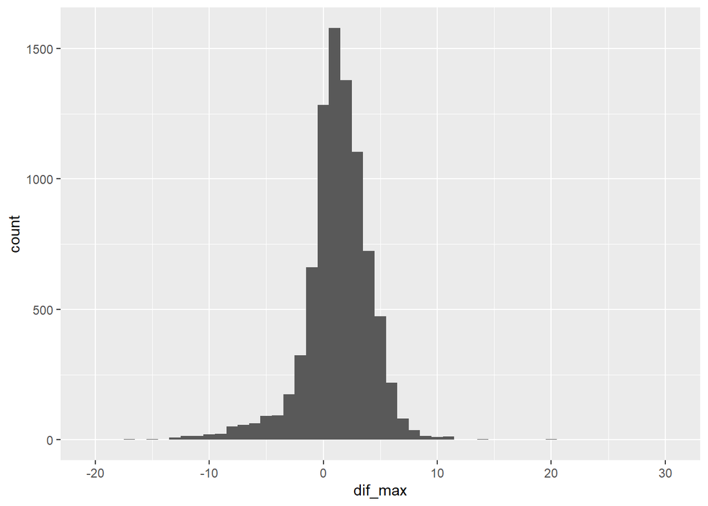

```r
ggplot(problem_2, aes(dif_max))+
  geom_histogram(binwidth=1)
```

### 3

Repeat the previous problem with the daily minimum temperature.

Answer: The distribution looks to be skew left, with a few straggling values on the right.  
The mean of the data is -2.632739, the standard deviation is 3.801263, the median is -2 and the IQR is 5. This means that this data is distributed with more variation than the last problem. There are a few extreme values to the right of the general distribution.

```r
#P3
problem_3 = problem_1%>%
  select(date, tmin_Airport, tmin_Bureau)%>%
  drop_na(tmin_Airport, tmin_Bureau)%>%
  mutate(dif_min =
           tmin_Airport-tmin_Bureau,)
p3_mw_sum = problem_3%>%
  summarise(avg = mean(dif_min),
            dev = sd(dif_min),
            med = median(dif_min),
            iqr = IQR(dif_min))
  drop_na(problem_3, dif_min)
```

```
## # A tibble: 8,528 x 4
##    date       tmin_Airport tmin_Bureau dif_min
##    <date>            <dbl>       <dbl>   <dbl>
##  1 1939-10-01           33          35      -2
##  2 1939-10-02           38          42      -4
##  3 1939-10-03           48          47       1
##  4 1939-10-04           51          55      -4
##  5 1939-10-05           56          58      -2
##  6 1939-10-06           45          52      -7
##  7 1939-10-07           47          55      -8
##  8 1939-10-08           59          59       0
##  9 1939-10-09           58          59      -1
## 10 1939-10-10           44          44       0
## # ... with 8,518 more rows
```

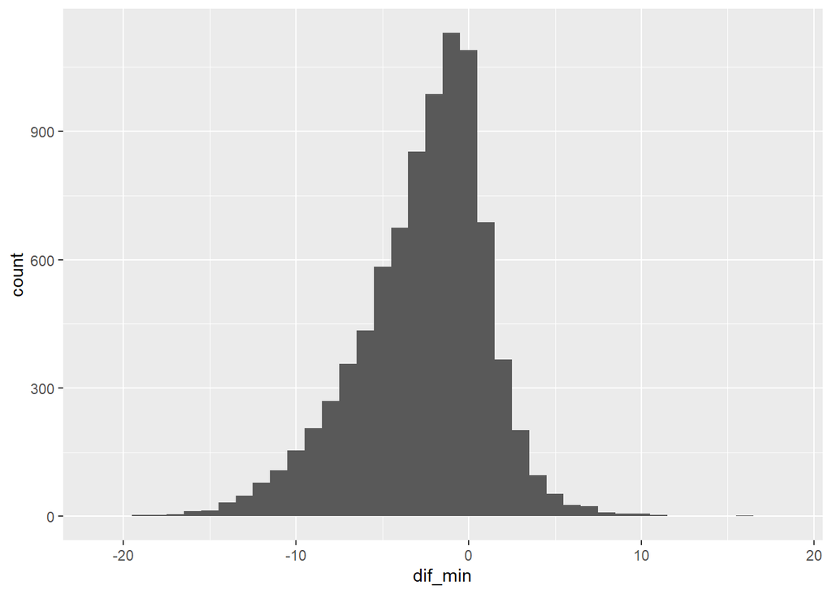

```r
ggplot(problem_3, aes(dif_min))+
  geom_histogram(binwidth=1)
```

### 4

Using the official Madison weather data, use code from class to create a data set with the dates and snowfall amounts from January 1, 1884 to the present where you replace missing snowfall totals with zero if the precipitation is zero and drop dates where the snowfall measurements are missing. Find the total annual snowfall by year and plot this. Add a trend line. Describe any patterns. How has total snowfall been changing in Madison? About how much does the actual snowfall in a given year tend to vary from the trend?

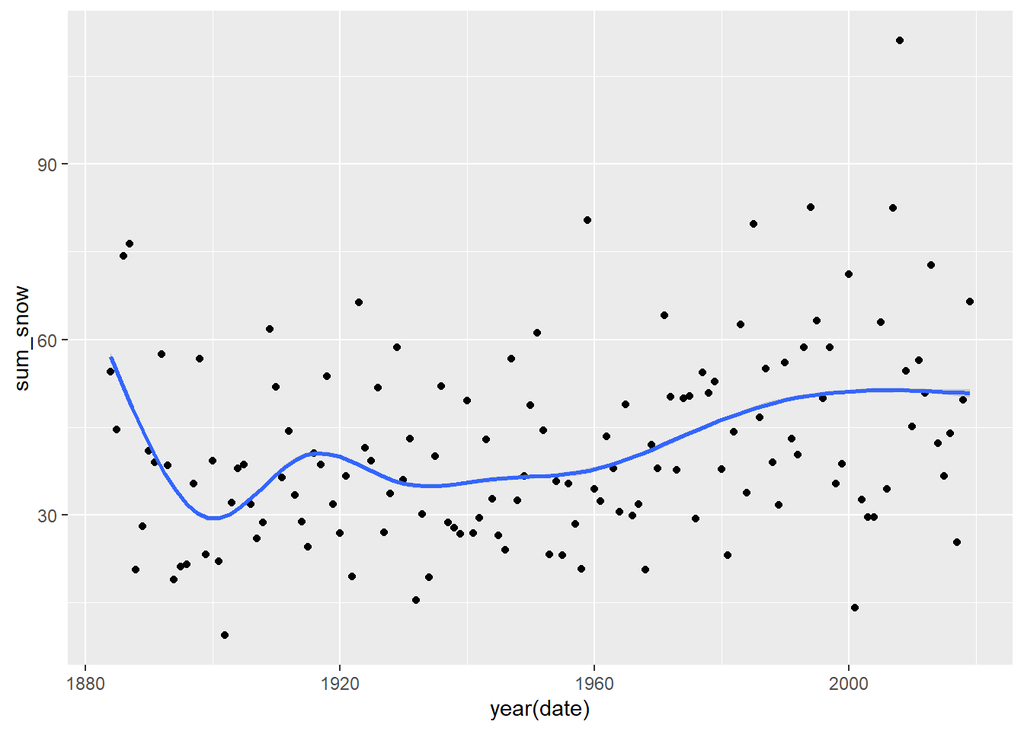

```r
problem_4 = official%>%
  group_by(date)%>%
  select(date, snow, prcp)%>%
  filter(date>"1884-01-01")

problem_4_temp = problem_4%>%
  select(date, snow, prcp)%>%
  filter(is.na(snow), .preserve=TRUE)%>%
  drop_na(prcp)%>%
  mutate(snow=0.00)

problem_4 = problem_4%>%
  full_join(problem_4, problem_4_temp, by=NULL)%>%
  drop_na(snow)%>%
  group_by(year(date))%>%
  mutate(sum_snow = max(cumsum(snow)))

ggplot(problem_4, aes(x=year(date), y=sum_snow))+
  geom_point()+ geom_smooth()
```

### 5

```r
problem_5=official%>%
  mutate(year=year(date),
         year_2=year+1)%>%
  group_by(year, year_2)%>%
  filter(year>1884)%>%
  mutate(winter_start=make_datetime(year=year,month=11,day = 01),
         winter_end=make_datetime(year=year_2,month=04, day=30))%>%
  filter(date>winter_start, snow!=0)%>%
  mutate(first_snow=first(date))%>%
  summarise(earliest_by_year=min(first_snow))

problem_5_temp=official%>%
  mutate(year=year(date),
         year_2=year+1)%>%
  group_by(year, year_2)%>%
  filter(year>1885)%>%
  mutate(winter_start=make_datetime(year=year,month=11,day = 01),
         winter_end=make_datetime(year=year_2,month=04, day=30))%>%
  filter(date+years(1)<winter_end, snow!=0)%>%
  mutate(last_snow=last(date))%>%
  summarise(latest_by_year=max(last_snow))

p5_max_sum = problem_5_temp%>%
  ungroup()%>%
  mutate(latest_by_year=make_datetime(month=month(latest_by_year),day=day(latest_by_year)))%>%
  summarise(record_latest=max(latest_by_year))

p5_min_sum = problem_5%>%
  ungroup()%>%
  mutate(earliest_by_year=make_datetime(month=month(earliest_by_year),day=day(earliest_by_year)))%>%
  summarise(record_earliest=min(earliest_by_year))
```

### 6

Find the record snowfall amount for each day of the year and plot this data. Which day in January or February has the lowest record snowfall?

Answer: The lowest days in January in terms of record snowfall are the 10th and the 22nd, and the lowest day in February is the 29th; this is likely due to the infrequency of leap years.

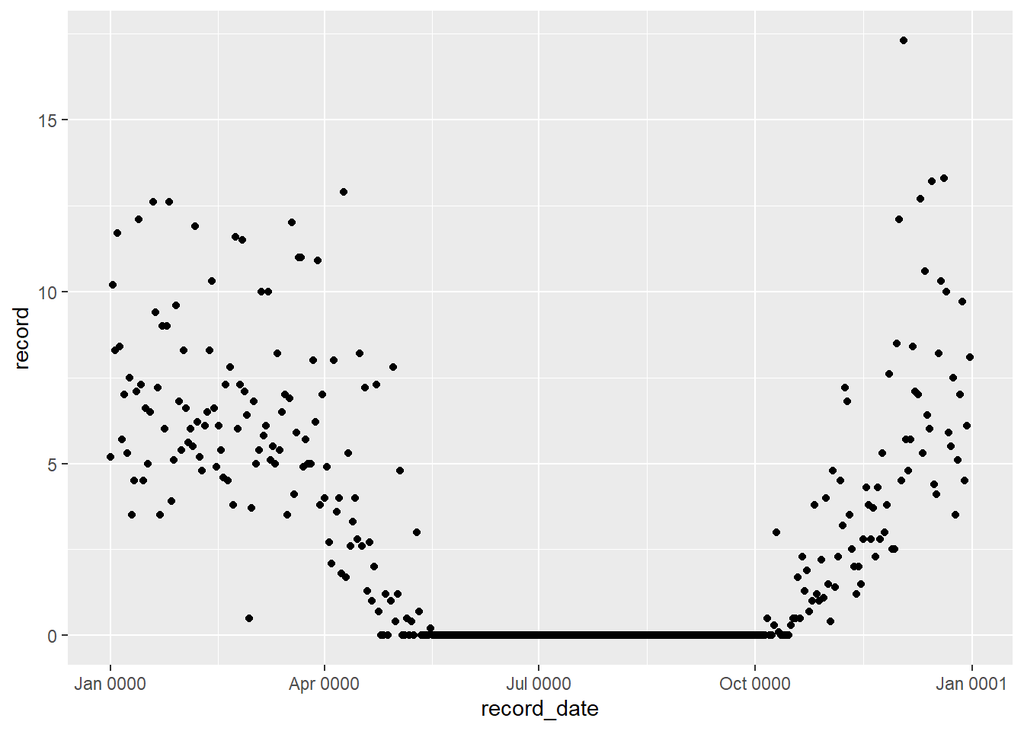

```r
problem_6=official%>%
  drop_na(snow)%>%
  group_by(month(date),day(date))%>%
  mutate(record=max(snow),
         record_date=make_datetime(year=0000, month= month(date),day=day(date)))
ggplot(problem_6, aes(record_date, record))+
  geom_point()
```

```r
p6_sum = problem_6%>%
  ungroup()%>%
  filter(month(date)==01)%>%
  filter(record==min(record))%>%
  summarize(min_1=first(day(date)),
            min_2=last(day(date)))

p6_sum_2 = problem_6%>%
  ungroup()%>%
  filter(month(date)==02)%>%
  filter(record==min(record))%>%
  summarize(min_1=first(day(date)),
            min_2=last(day(date)))
```